# Lab 06, Experiment 1

# LPF with Trapezoidal Frequency Response.

```python
%matplotlib inline
```

```python
# Importing all required modules

import pam11 as pam
import showfun as sf
import wavfun as wf
```

# Part (a)

**To generate a module "filtfun" with "trapfilt" function that generates a truncated version hT(t) of the trapeziodal frequency response which will further generate a delay compensated filtered output of input signal x(t).**

```python
# writefile filtfun.py
# Module for filter functions
from pylab import *
from scipy.signal import butter, lfilter
def trapfilt(xt, Fs, fL, k, alfa):
    """
    Delay compensated FIR LPF with trapezoidal frequency response.
    >>>>> yt, n = trapfilt(xt, Fs, fL, k, alfa) <<<<<
    where yt: filter output y(t), sampling rate Fs
    n:  filter order
    xt: filter input x(t), sampling rate Fs
    Fs: sampling rate of x(t), y(t)
    fL: cutoff frequency (-6 dB) in Hz
    k:  h(t) is truncated to |t| <= k/(2fL)
    alfa: frequency rolloff parameter, linear rolloff
    over range (1-alfa)fL <= |f| <= (1+alfa)fL
    """
    ixk = round(Fs*k/float(2*fL))                                # Tail cutoff index
    tt = arange(-ixk,ixk+1)/float(Fs)                            # Time axis for h(t)
    n = len(tt)-1                                                # Filter order

    # ***** Generate impulse response ht here *****
    ht = zeros(len(tt))
    ix = where(tt != 0)[0]
    if alfa != 0:
        ht[ix] = ((sin(2*pi*fL*tt[ix]))/(pi*tt[ix]))*((sin(2*pi*alfa*fL*tt[ix]))/(2*pi*alfa*fL*tt[ix]))
    else:
        ht[ix] = ((sin(2*pi*fL*tt[ix]))/(pi*tt[ix]))
    ix0 = where(tt == 0)[0]
    ht[ix0] = 2*fL

    # Filtering the input signal
    yt = lfilter(ht, 1, hstack((xt, zeros(ixk))))/float(Fs)      # Compute filter output y(t)
    yt = yt[ixk:]                                                # Filter delay compensation
    return yt, n                                                 # Return y(t) and filter order
```

**The module 'filtfun' has been created with 'trapfilt' function. This function will be used in next part to plot the frequency response of the input impulse.**

# Part (b)

**To test trapfilt with Fs = 16000 Hz, time axis from -0.5 to 0.5 sec, using a unit impulse at t = 0. This has to be (an approximation to) a CT unit impulse (with area 1 under the impulse). Plot the frequency response of the output of 'trapfilt' with fL = 1000Hz, k = 20 and α = 0.2.**

```python
tlen = 1                                                          # Time length (-0.5, 0.5)
Fs = 16000                                                        # Sampling Frequency
ixL = ceil(-Fs * 0.5)                                             # Left index of time
ixR = ceil(Fs * 0.5)                                              # Right index of time
tt = arange(ixL,ixR+1)/Fs                                         # Time axis
ns = ixR - ixL + 1                                                # Number of samples
st = hstack((zeros(int(ns/2)),Fs*ones(1),zeros(int(ns/2))))       # Impulse with area 1
```

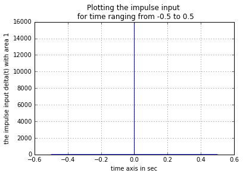

```python
# plotting the impulse input to the filter with time
plot(tt,st)
ylabel('the impulse input delta(t) with area 1')
xlabel('time axis in sec')
title('Plotting the impulse input \n for time ranging from -0.5 to 0.5')
grid()
show()
```

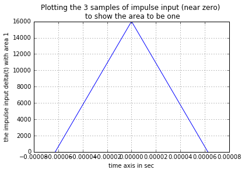

```python
# plotting the 3 samples (around non-zero value) of impulse input to the filter with time

plot(tt[int(ns/2)-1:int(ns/2)+2],st[int(ns/2)-1:int(ns/2)+2])
ylabel('the impulse input delta(t) with area 1')
xlabel('time axis in sec')
title('Plotting the 3 samples of impulse input (near zero) \n to show the area to be one')
grid()
show()
```

**We can see in the above plot that the area under the impulse is 1. Now, we will plot the frequency response of the output of trapfilt function.**

```python
yt,n=trapfilt(st, Fs, fL=1000, k=20, alfa=0.2)                  # Making output of trapfilt function using impulse input
```

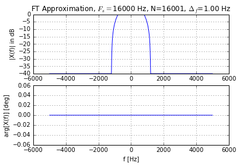

```python
sf.showft(tt,yt,[-5000,5000,-40])                             # Plotting the frequency repsonse in dB
```

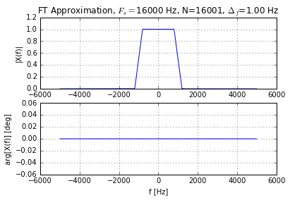

```python
sf.showft(tt,yt,[-5000,5000,1e-1])                           # Plotting the frequency repsonse in dB
```

**We can see in the above plot that the impulse frequency response of the output of the filter is exact what is given in the lab manual. We can also observe that the passband has a magnitude of 1 and that the transition from passband to stopband is linear.**

**When we put alfa = 0, the term containing alfa (sin(2*pi*fL*t)/2*pi*fL*t) is approximated to 1 for any t. Below is the output with alfa = 0 and the frequency plot.**

```python
yt,n=trapfilt(st, Fs, 1000, k=20, alfa=0)                  # Making output of trapfilt function using impulse input
```

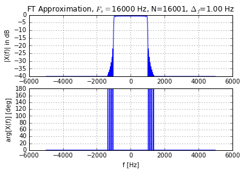

```python
sf.showft(tt,yt,[-5000,5000,-40])                             # Plotting the frequency repsonse in dB
```

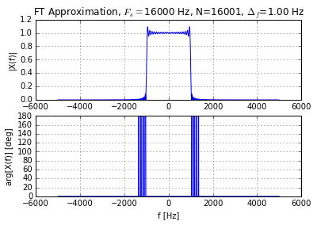

```python
sf.showft(tt,yt,[-5000,5000,1e-2])                             # Plotting the frequency repsonse in dB
```

**For alfa = 0, the impulse response of the filter is rectangular in nature.**

# Part (c)

**file pamsig601.wav contains a noisy polar binary PAM signal. Look at the PSD of this signal and then use trapfilt to lowpass filter the signal with fL ≈ 1000 Hz, k ≈ 10 and α ≈ 0.2. Determine the baud rate F B (look at the PSD of the lowpass filtered signal squared), and then use this information to display the eye diagram (use a width of 3*TB and superimpose about 100 traces) of the lowpass filtered PAM signal. Change fL to find the value that gives you the largest eye opening. How is this fL related to FB ?**

```python
st,Fs = wf.wavread('pamsig601.wav')
```

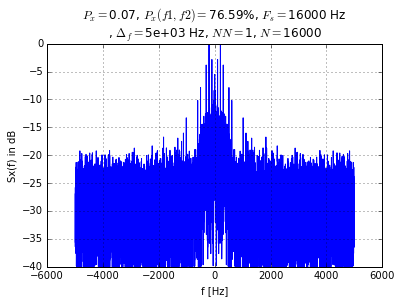

```python
# Looking at the PSD of the signal

sf.showpsd(st,Fs,[-5000,5000,-40],Fs)
```

```python
# Passing the signal to trapezoidal LPF

yt,n=trapfilt(st, Fs, fL=1000, k=10, alfa=0.2)
```

```python
# Squaring the filtered ouput of the signal

yt_sq = np.power(yt,2)
```

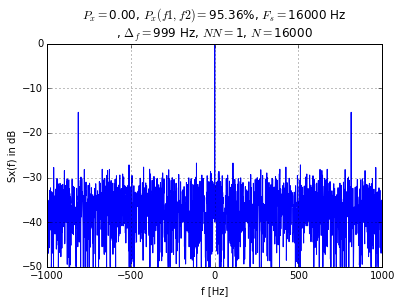

```python
# Looking at the PSD of squared signal to find the bit rate

sf.showpsd(yt_sq,Fs,[-1000,1000,-50],Fs)
```

**From the above plot of PSD of squared output of trapezoidal filter, we find the baud rate to be 815 Hz.**

**Using the above baud rate, we will try to find the eye-diagram of the signal and also try to get the fL which gives best eye-opening.**

```python
FB = 815      # the baud rate found to be 815 hz
```

**For fL = 1000 Hz**

```python
fL = 1000
yt,n=trapfilt(st, Fs, fL, k=10, alfa=0.2)            # filtering the pamsig401.wav signal
```

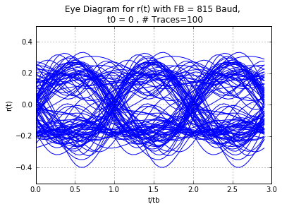

```python
sf.showeye(yt,Fs,FB,NTd=100,dispparms=[0,3,-0.5,0.5])
```

**fL = 800 Hz**

```python
fL = 800
yt,n=trapfilt(st, Fs, fL, k=10, alfa=0.2)                    # filtering the pamsig401.wav signal
```

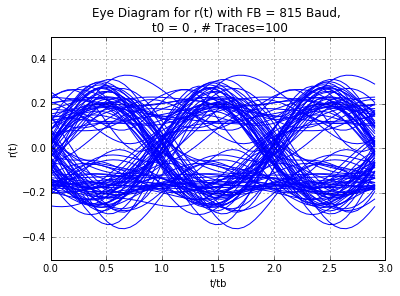

```python
sf.showeye(yt,Fs,FB,NTd=100,dispparms=[0,3,-0.5,0.5])
```

**fL = 600 Hz**

```python
fL = 600
yt,n=trapfilt(st, Fs, fL, k=10, alfa=0.2)                         # filtering the pamsig401.wav signal
```

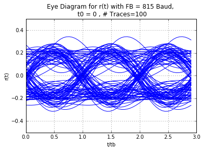

```python
sf.showeye(yt,Fs,FB,NTd=100,dispparms=[0,3,-0.5,0.5])
```

**fL = 500 Hz**

```python
fL = 500
yt,n=trapfilt(st, Fs, fL, k=10, alfa=0.2)                            # filtering the pamsig401.wav signal
```

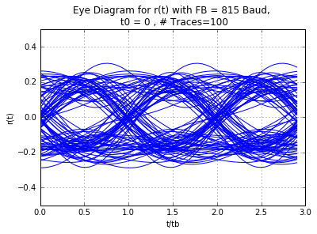

```python
sf.showeye(yt,Fs,FB,NTd=100,dispparms=[0,3,-0.5,0.5])
```

**fL = 300 Hz**

```python
fL = 300
yt,n=trapfilt(st, Fs, fL, k=10, alfa=0.2)                            # filtering the pamsig401.wav signal
```

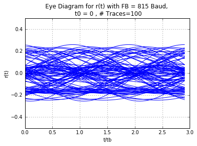

```python
sf.showeye(yt,Fs,FB,NTd=100,dispparms=[0,3,-0.5,0.5])
```

**From the above plots, we observe following: We start from fL = 1000 Hz and decrease the fL. As, we decrease the fL, the noise power in signal is decreasing. But, after fL = 500, we observe that as we decrease the fL value, the eye-opening starts getting smaller by the time jitter. Therefore, in the above plots, the eye-opening appears to be best around 500 Hz.**

**Also, we observe that the fL = 0.6*FB (approximately) is giving better eye-diagram.**